# Статистический анализ

Переверзев Дмитрий

23.12.2020

### **Индивидуальное домашнее задание №3**

### **Вариант 18**

#### Результаты статистического эксперимента приведены в таблице 1. Требуется оценить характер (случайной) зависимости переменной Y от переменной X.

##### Таблица 1. $\alpha_1 = 0.10; h = 2.80$

```
##    [,1]  [,2]  [,3]  [,4]  [,5]  [,6] [,7] [,8] [,9] [,10] [,11] [,12] [,13]
## x  5.00  5.00  4.00  3.00  6.00  2.00 2.00 4.00 0.00  0.00   2.0  1.00  5.00
## y 18.13 35.07 11.95 12.34 15.09 25.97 6.23 6.98 9.33  1.72   3.3 20.49  6.83
##   [,14] [,15] [,16] [,17] [,18] [,19] [,20] [,21] [,22] [,23] [,24] [,25] [,26]
## x  0.00  5.00  6.00  4.00  0.00  3.00  5.00   3.0  3.00  2.00  1.00  0.00  5.00
## y  3.13 22.18  5.01 15.22 22.14  6.78 12.35   2.1  9.48 12.63  8.68 28.42 39.03
##   [,27] [,28] [,29] [,30] [,31] [,32] [,33] [,34] [,35] [,36] [,37] [,38] [,39]
## x  2.00  0.00  6.00  3.00  4.00   2.0  2.00  1.00  0.00  4.00  1.00  6.00  4.00
## y 17.77 19.11 12.83 17.75  4.25  15.1  0.14 18.32 13.17 12.72 16.93 23.14 23.04
##   [,40] [,41] [,42] [,43] [,44] [,45] [,46] [,47] [,48] [,49] [,50]
## x  0.00  5.00  4.00  3.00   5.0  2.00  5.00  4.00  3.00  1.00  3.00
## y 20.18  3.57  7.98 21.42  10.5  5.87 19.63 17.04 17.21 28.83  9.45
```

#### **Пункт (a)**

##### Построить графически результаты эксперимента. Сформулировать линейную регрессионную модель переменной Y по переменной X. Построить МНК оценки параметров сдвига $\beta_0$ и масштаба $\beta_1$. Построить полученную линию регрессии. Оценить визуально соответствие полученных данных и построенной оценки.

$$\begin{align}
& Y_i = \beta_0+\beta_1X_i + \varepsilon_i, \varepsilon_i - N(0, \sigma^2) \\
& \beta_1 = \frac{\bar{xy}-\bar{x}\bar{y}}{\bar{x^2}-\bar{x}^2} = 0.1902404; \beta_0 = \bar{Y} - \beta_1\bar{X} = 13.775098 \\
& Y = \hat{\beta_1}X + \beta_0 = 0.1902404X + 13.775098
\end{align}$$

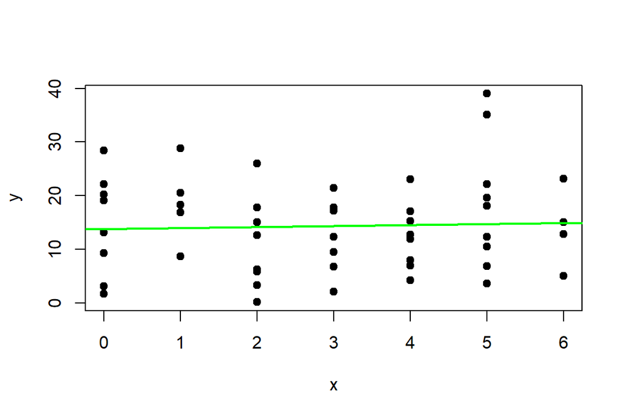

#### **Пункт (b)**

##### Построить и интерпретировать несмещенную оценку дисперсии. На базе ошибок построить гистограмму с шагом $h$. Проверить гипотезу нормальности ошибок на уровне $\alpha_1$ по $\chi^2$. Оценить расстояние полученной оценки до класса нормальных распределений по Колмогорову. Визуально оценить данный факт.

$$\begin{align}
\hat{\sigma}^2=\frac{1}{n-2}&\sum\limits_{1}^{n}(Y-\bar{Y})^2 = 76.2468392; \varepsilon_i=Y_i -\hat{\beta_1}X_i - \hat{\beta_0}
\end{align}$$

###### $\varepsilon_1, ..., \varepsilon_n(sorted):$

```
##  [1] -14.0155788 -12.2458192 -12.0550980 -11.1563001 -10.8555788 -10.6450980
##  [7] -10.2860597  -9.9065405  -8.2855788  -7.9255788  -7.8963001  -7.5658192
## [13]  -7.5560597  -6.5560597  -5.2853384  -4.8958192  -4.8658192  -4.4450980
## [19]  -4.2263001  -2.5860597  -2.3763001  -2.0865405  -2.0058192  -1.8160597
## [25]  -1.5255788  -0.6050980   0.1734595   0.6839403   0.9444212   2.5039403
## [31]   2.8641808   2.9646616   3.4036999   3.4041808   3.6144212   4.3546616
## [37]   4.9036999   5.3349020   6.4049020   6.5246616   7.0741808   7.4536999
## [43]   8.2234595   8.3649020   8.5039403  11.8144212  14.6449020  14.8646616
## [49]  20.3436999  24.3036999
```

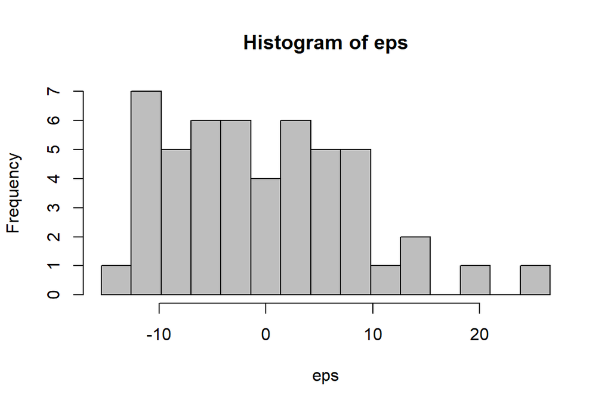

$H_0:\varepsilon_1, ..., \varepsilon_n \sim N(0, \sigma^2);$  
Минимизация хи-квадрат: $\underset{\sigma^2}{argmin}\sum\limits_{i=1}^{r}\frac{n_i-np_i(0, \sigma^2))^2}{np_i(0, \sigma^2)}$

##### Делим выборку на 6 интервалов

| Интервал | $(-\infty; -10.0)$ | $(-10.0; -5.0)$ | $(-5.0; 0)$ | $(0; 5.0)$ | $(5.0; 10.0)$ | $(10.0; \infty)$ |
| --- | --- | --- | --- | --- | --- | --- |
| Частота | 7 | 8 | 11 | 11 | 8 | 5 |

Получили $\hat{\sigma}^2=73.3904593$ и $\chi^2_{набл}=0.3331803$  
$\chi^2_{набл}=0.3331803 < \chi^2_{кр} = 7.7794403 \Rightarrow$ гипотеза H_0 принимается

Оценим расстояние оценки до класса нормальных распределений по Колмогорову.  
Минимизируем статистику Колмогорова с помощью скрипта:

```r
kolm.stat<-function(s){
  sres<-sort(eps)
  fdistr<-pnorm(sres,0,s)
  max(abs(c(0:(n-1))/n-fdistr),abs(c(1:n)/n-fdistr))
}
ks.dist<-nlm(kolm.stat, XM$estimate)
```

Получили расстояние $D = 0.068403$ и $\tilde{\sigma}^2 = 78.3880132$.

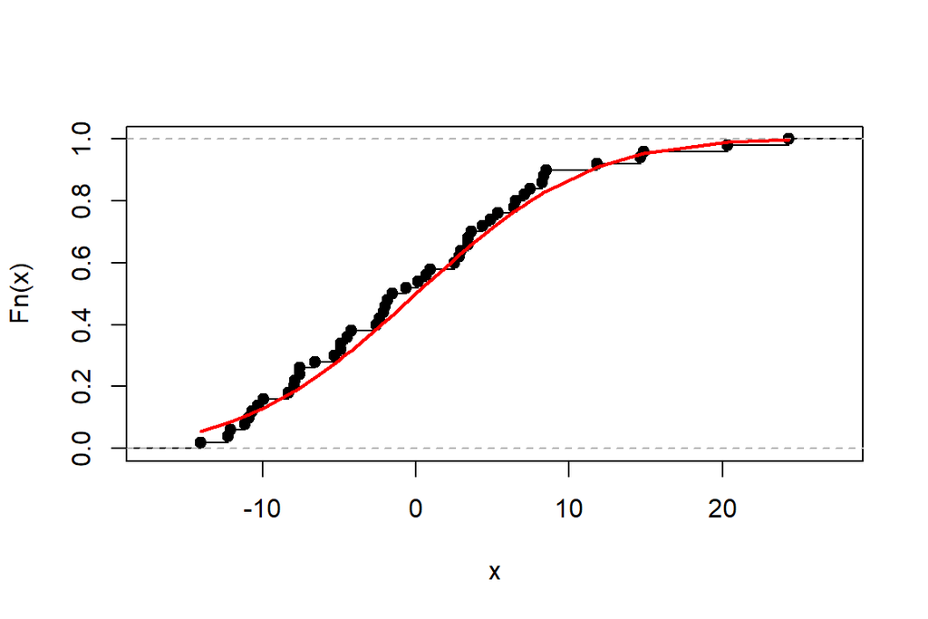

#### **Пункт (c)**

##### В предположении нормальности ошибок построить доверительные интервалы для параметров $\beta_0$ и $\beta_1$ уровня доверия $1-\alpha_1$. Построить доверительный эллипс уровня доверия $1-\alpha_1$ для $(\beta_0, \beta_1)$ (вычислить его полуоси).

$\psi=C^T\beta$  
$\hat{\psi}\sim N(\psi, \sigma^2b), \sigma^2b=var(\hat{\psi})=\sigma^2C^T(XX^T)^{-1}C$  
$\frac{\hat{\psi}-\psi}{\sigma\sqrt{b}}\sim N(0, 1);\frac{(n-r)s^2}{\sigma^2}\sim \chi^2_{n-r}\Rightarrow \frac{\hat{\psi}-\psi}{s\sqrt{b}}\sim S_{n-r}$  
$x_{\alpha}:S_{n-r}(x_{\alpha})=1-\frac{\alpha}{2}; x_{\alpha}=1.6772242$  
$P(-x_{\alpha} \leqslant \frac{\hat{\psi}-\psi}{s\sqrt{b}} \leqslant x_{\alpha})=P(\hat{\psi}-x_{\alpha}s\sqrt{b} \leqslant \psi \leqslant \hat{\psi}+x_{\alpha}s\sqrt{b})$  
$\beta_0 \in (9.9714223; 17.5787737)$  
$\beta_1 \in (-0.9023369; 1.2828177)$

$\frac{(\hat{\psi}-\psi)^T(C^T(XX^T)^{-1}C)^{-1}(\hat{\psi}-\psi)}{\sigma^2}\sim\chi^2_q$

$x_{\alpha}: F_{q, n-r}(x_{\alpha})=1-\alpha$  
$\left\{ \psi: (\hat{\psi}-\psi)^T(C^T(XX^T)^{-1}C)^{-1}(\hat{\psi}-\psi) \leqslant s^2qx_{\alpha} \right\}$  
$x_{\alpha} = 2.4166601$  
$\begin{pmatrix} \beta_1-\hat{\beta_1} & \beta_0-\hat{\beta_0} \end{pmatrix} \begin{pmatrix} 0.0055654 & -0.0162511 \\ -0.0162511 & 0.0674533 \end{pmatrix} \begin{pmatrix} \beta_1-\hat{\beta_1} \\ \beta_0-\hat{\beta_0} \end{pmatrix} \leqslant 368.5253897$

Собственные числа матрицы: 0.0714611, 0.0015576  
После ортогонального преобразования получаем:

$0.0714611(\beta_1^*-0.1902404)^2+0.0015576(\beta_0^*+13.775098)^2 \leqslant 368.5253897$
$$\frac{(\beta_1^*-0.1902404)^2}{71.8123122^2}+\frac{(\beta_0^*+13.775098)^2}{486.4109861^2} \leqslant 1$$
Полуоси эллипса: 71.8123122; 486.4109861.

#### **Пункт (d)**

##### Сформулировать гипотезу независимости переменной Y от переменной X. Провести проверку значимости.

$\psi=C^T\beta; \hat{\psi}\sim N(\psi, \sigma^2C^T(XX^T)^{-1}C)$  
$H_0: \psi=0$  
Статистика F-критерия: $F=\frac{\hat{\psi^T(C^T(XX^T)^{-1}C)^{-1}\hat{\psi}}}{qs^2}\overset{H_0}{\sim}F_{q, n-r}$  
$F=0.0852871$  
$x_{\alpha}: F_{q, n-r}(x_{\alpha})=1-\alpha; x_{\alpha}=2.813081$  
$H_1: \hat{\psi}=\beta_1$

$F<x_{\alpha}\Rightarrow$ Принимаем гипотезу $H_0$.  
$0.7715149$ – наибольшее значение уровня значимости, на котором нет оснований отвергнуть данную гипотезу.

#### **Пункт (e)**

##### Сформулировать модель, включающую дополнительный член с $X^2$. Построить МНК оценки параметров $\beta_1, \beta_2, \beta_3$ в данной модели. Изобразить графически полученную регрессионную зависимость.

$$\begin{align}
& Y_i = \beta_3+\beta_2X_i+\beta_1X_i^2+\varepsilon_i, \varepsilon_i\sim N(0, \sigma^2) \\
& \hat{\beta}=(X^TX)^{-1}X^TY \\
& \hat{\beta}=\begin{pmatrix}\hat{\beta_1} \\ \hat{\beta_2} \\ \hat{\beta_3}\end{pmatrix}=\begin{pmatrix}0.405228 \\ -2.1022026 \\ 15.5576681\end{pmatrix}
\end{align}$$

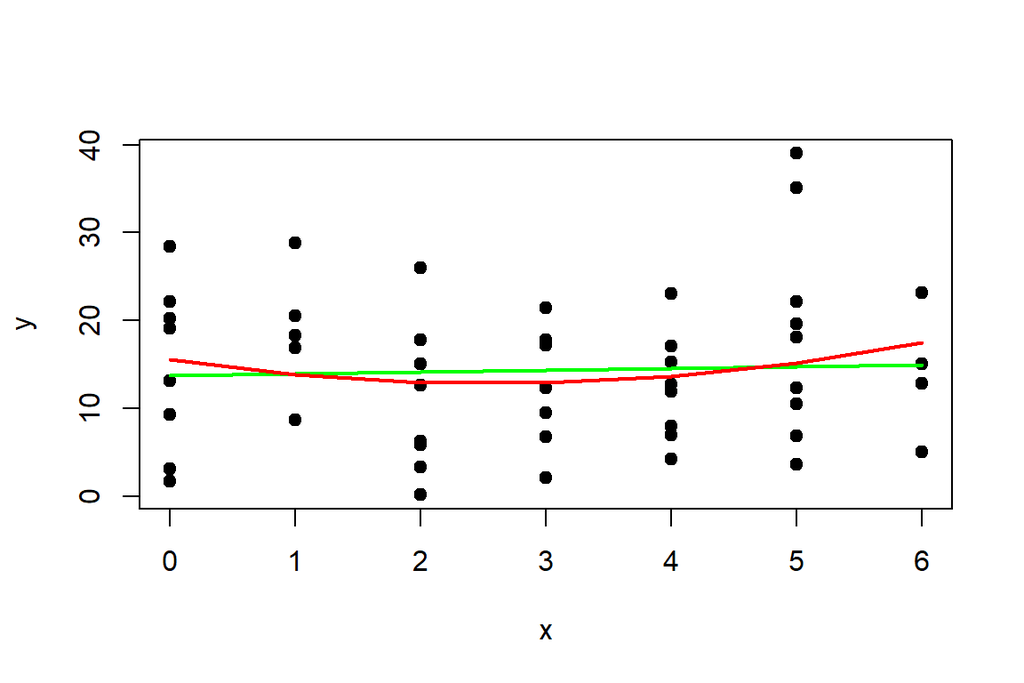

#### **Пункт (f)**

##### Построить несмещенную оценку дисперсии. Провести исследование нормальности ошибок как в п.3.

$\hat{\sigma}^2=\frac{1}{n-3}\sum\limits_{1}^{n}(Y_i-\hat{\beta_1}X_i^2-\hat{\beta_2}X_i-\hat{\beta_3})^2 = 75.8340207; \varepsilon_i=\hat{Y}-X^T\hat{\beta}$

###### $\varepsilon_1, ..., \varepsilon_n(sorted):$

```
##  [1] -13.8376681 -12.8341750 -12.5226607 -12.4276681 -11.6073553 -10.7981124
##  [7]  -9.6741750  -9.3825059  -8.3473553  -7.1041750  -6.7441750  -6.6525059
## [13]  -6.2276681  -6.1181124  -5.6525059  -5.1806936  -4.7026607  -4.6773553
## [19]  -3.4481124  -3.4181124  -2.8273553  -2.4426607  -2.3876681  -1.6825059
## [25]  -0.9125059  -0.5581124  -0.3441750   1.5874941   2.1258250   2.9526447
## [31]   3.0693064   3.4074941   3.5523319   4.3118876   4.4526447   4.4593064
## [37]   4.6223319   4.7958250   4.8518876   5.6073393   6.5823319   6.6293064
## [43]   7.0026447   8.5218876   9.4074941  12.8623319  12.9958250  14.9693064
## [49]  19.8926447  23.8526447
```

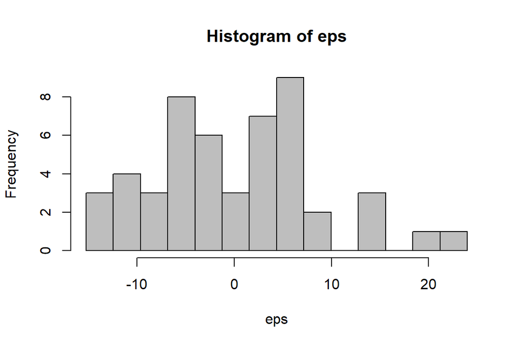

$H_0:\varepsilon_1, ..., \varepsilon_n \sim N(0, \sigma^2)$  
Минимизация хи-квадрат: $\underset{\sigma^2}{argmin}\sum\limits_{i=1}^{r}\frac{n_i-np_i(0, \sigma^2))^2}{np_i(0, \sigma^2)}$

Делим выборку на 6 интервалов

| Интервал | $(-\infty; -10.0)$ | $(-10.0; -5.0)$ | $(-5.0; 0)$ | $(0; 5.0)$ | $(5.0; 10.0)$ | $(10.0; \infty)$ |
| --- | --- | --- | --- | --- | --- | --- |
| Частота | 6 | 10 | 11 | 12 | 6 | 5 |

Получили $\hat{\sigma}^2=66.4715803$ и $\chi^2_{набл}=1.1353156$  
$\chi^2_{набл}=1.1353156 < \chi^2_{кр} = 7.7794403 \Rightarrow$ гипотеза $H_0$ принимается

Оценим расстояние оценки до класса нормальных распределений по Колмогорову.  
Минимизируем статистику Колмогорова.

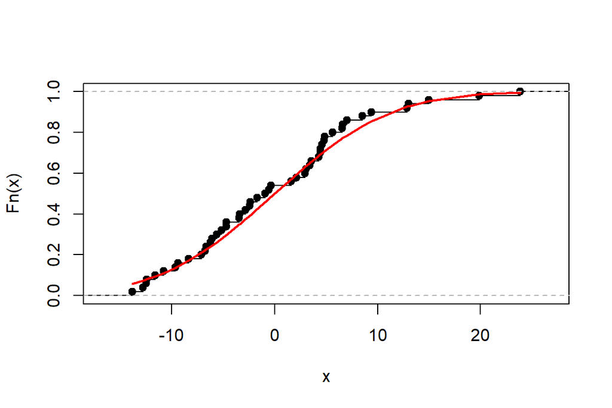

#### **Пункт (g)**

##### В предположении нормальности ошибок построить доверительные интервалы для параметров $\beta_1, \beta_2, \beta_3$ уровня $1-\alpha_1$. Написать уравнение доверительного эллипсоида уровня доверия $1-\alpha_1$.

$\psi=C^T\beta; \hat{\psi}\sim N(\psi, \sigma^2C^T(XX^T)^{-1}C)$
$x_{\alpha}: S_{n-r}(x_{\alpha})=1-\frac{\alpha}{2}; x_{\alpha} = 1.6779267$
$P(\hat{\psi}-x_{\alpha}s\sqrt{b} \leqslant \psi \leqslant \hat{\psi}+x_{\alpha}s\sqrt{b})$
$$\beta_1 \in (-0.2218946; 1.0323506)$$
$$\beta_2 \in (-5.8136314; 1.6092263)$$
$$\beta_3 \in (10.8659807; 20.2493555)$$

$x_{\alpha}: F_{q, n-r}(x_{\alpha})=1-\alpha; x_{\alpha} = 2.2041824$  
$\left\{ \psi: (\hat{\psi}-\psi)^T(C^T(XX^T)^{-1}C)^{-1}(\hat{\psi}-\psi) \leqslant s^2qx_{\alpha} \right\}$  
$\begin{pmatrix} \beta_1-\hat{\beta_1} & \beta_2-\hat{\beta_2} & \beta_3-\hat{\beta_3} \end{pmatrix} \begin{pmatrix} 0.001842 & -0.0104206& 0.0081029 \\ -0.0104206 & 0.0645167 & -0.0620908 \\ 0.0081029 & -0.0620908 & 0.1030975 \end{pmatrix} \begin{pmatrix} \beta_1-\hat{\beta_1} \\ \beta_2-\hat{\beta_2} \\ \beta_3-\hat{\beta_3} \end{pmatrix} \leqslant 501.4560391$

Собственные числа матрицы: 0.1499161, 0.0194699, 7.024460710^{-5}  
После ортогонального преобразования получаем:

$0.1499161(\beta_1^*-0.405228)^2+0.0194699(\beta_2^*-(-2.1022026))^2+7.0244607\times 10^{-5}(\beta_3^*-15.5576681)^2 \leqslant 501.4560391$
$$\frac{(\beta_1^*-0.405228)^2}{57.8352148^2}+\frac{(\beta_2^*-(-2.1022026))^2}{160.4849927^2}+\frac{(\beta_3^*-15.5576681)^2}{2671.8368734^2} \leqslant 1$$

Полуоси эллипсоида: 57.8352148; 160.4849927; 2671.8368734.

#### **Пункт (h)**

##### Сформулировать гипотезу линейной регрессионной зависимости переменной Y от переменной X и проверить ее значимость на уровне $\alpha_1$.

$\psi=C^T\beta; \hat{\psi}\sim N(\psi, \sigma^2C^T(XX^T)^{-1}C)$  
$H_0: \psi=0$  
Статистика F-критерия:  
$F=\frac{\hat{\psi^T(C^T(XX^T)^{-1}C)^{-1}\hat{\psi}}}{qs^2}\overset{H_0}{\sim}F_{q, n-r}$  
$F=1.1755467$  
$x_{\alpha}: F_{q, n-r}(x_{\alpha})=1-\alpha; x_{\alpha}=2.8154381$  
$H_1: \hat{\psi}=\beta_1$

$F<x_{\alpha}\Rightarrow$ Принимаем гипотезу $H_0$.  
$0.283795$ – наибольшее значение уровня значимости, на котором нет оснований отвергнуть данную гипотезу.